# Processus de Galton-Watson

## Qu'est ce que le processus de Galton-Watson

## 1. Définition du modéle et propriétés

Soit $X$ une **variable aléatoire intégrable** à valeurs dans $\mathbb{N}$.  
On note, pour tout $k \in \mathbb{N}$ :

$$ p_k = \mathbb{P}(X = k) $$

et on définit l’**espérance** de $X$ par :

$$ m = \mathbb{E}[X] = \sum_{k=0}^{\infty} k \cdot p_k < \infty $$

Soit maintenant une **famille dénombrable de variables aléatoires indépendantes et identiquement distribuées (v.a. i.i.d.)** de loi $p$ = $\mathbb{P}_X$ :

$$ (X_{n,i})_{n \in \mathbb{N},\, i \in \mathbb{N}^*} $$

où chaque $X_{n,i}$ suit la loi $p$.

### Définition

On se donne également une variable aléatoire $Z_0$ **indépendante** de la famille $(X_{n,i})$.  
Le **processus de Galton-Watson** est la suite de variables aléatoires $(Z_n)_{n \geq 0}$ définie par récurrence :

$$ Z_{n+1} = \sum_{i=1}^{Z_n} X_{n,i}, \quad \forall n \geq 0 \tag{1} $$

avec la convention que **la somme de $i = 1$ à $0$ vaut 0**.

On observe alors que :

- Si $Z_0 = 1$, alors $Z_1 = X_{0,1}$ suit la loi $p$.
- À chaque génération $n$, chaque individu vivant (parmi les $Z_n$) a un **nombre d’enfants suivant la loi $p$**, indépendamment des autres individus.

On appelle $p$ la **loi de reproduction**, et $Z_n$ représente le **nombre d’individus présent à la génération (ou date) $n$**.

La plupart du temps, on suppose que la population initiale est composée **d’un seul individu**, appelé **l’ancêtre**, c’est-à-dire :

$$ Z_0 = 1 $$

On introduit aussi les notations suivantes :

- $\pi_n := \mathbb{P}(Z_n = 0)$ : **probabilité que la population soit éteinte à la génération $n$**.
- $P_{\text{ext}} := \mathbb{P}(\exists n \in \mathbb{N},\, Z_n = 0)$ : **probabilité d'extinction finale**, c’est-à-dire la probabilité qu’il existe un instant $n$ où la population s’éteint.

Autrement dit, $P_{\text{ext}}$ est la **probabilité que la population s’éteigne un jour**, quelle que soit la génération.

### Cas particuliers pour $p_0$

Par exemple, si $X = 1$ presque sûrement (i.e. $p_1 = 1$ et $p_0 = 0$), alors chaque individu a toujours exactement un enfant, donc la population ne peut jamais s’éteindre.

- Si $p_0 = 1$, alors on a, pour tout $n \in \mathbb{N}^*$ :

  $$ Z_n = 0 \quad \text{presque sûrement}, \quad \text{et donc} \quad P_{\text{ext}} = 1 $$

  Dans ce cas, chaque individu a **zéro enfant** presque sûrement, donc la population s’éteint immédiatement.

On suppose donc désormais que :

$$ p_0 \in\, ]0, 1[ $$

c’est-à-dire que la probabilité d’avoir **zéro enfant est strictement positive mais inférieure à 1**, ce qui rend le modèle **aléatoire et non trivial**.

### 2. Fonction génératrice de $X$

Pour $0 \leq s \leq 1$, on définit la **fonction génératrice des probabilités** de $X$ par :

$$ G(s) = \mathbb{E}[s^X] = \sum_{k=0}^{\infty} p_k s^k $$

- Cette série converge pour tout $s \in [0, 1]$.
- Comme $G(s)$ est une somme de probabilités pondérées, on a :

$$ G(1) = \sum_{k=0}^{\infty} p_k = 1 $$

#### Proposition – Propriétés de la fonction génératrice $G$

1. La fonction $G$ est **bien définie sur** $[0, 1]$ et est de **classe $\mathcal{C}^1$** sur cet intervalle.
2. Propriétés sur l'intervalle $]0, 1[$ :

   a) $G$ est **strictement croissante** sur $]0, 1[$.  
   b) $G$ est **convexe** sur $]0, 1[$.  
   c) $G$ est **strictement convexe** sur $]0, 1[$ **si et seulement si** $p_0 + p_1 < 1$.

### 3. Fonction génératrice de $Z_n$ et relation de récurrence

Pour $n \in \mathbb{N}$, on note $G_n$ la **fonction génératrice** de la variable aléatoire $Z_n$, c’est-à-dire :

$$ G_n(s) = \mathbb{E}[s^{Z_n}] = \sum_{k=0}^{\infty} \mathbb{P}(Z_n = k) \cdot s^k $$

Comme pour $X$, on peut montrer que $G_n$ est bien définie sur l’intervalle $[0, 1]$.

- En particulier, on a : $$ G_n(0) = \mathbb{P}(Z_n = 0) = \pi_n $$
- De plus, la dérivée en $s = 1$ donne : $$ G_n'(1) = \mathbb{E}[Z_n] $$

C’est donc un outil utile pour relier l’évolution de la population aux propriétés analytiques de la fonction génératrice.

#### Proposition – Composition itérée de la fonction génératrice

Pour tout $n \in \mathbb{N}^*$, on a :

$$ G_n = G \circ G \circ \cdots \circ G \quad \text{($n$ fois)} $$

Autrement dit :

$$ G_n(s) = G(G_{n-1}(s)) = G(G(G_{n-2}(s))) = \cdots = G^{\circ n}(s), \quad \text{pour } s \in [0, 1] $$

### Démonstration

Soit $(Z_n)_{n \geq 0}$ un processus de Galton–Watson défini par :

$$ Z_{n+1} = \sum_{i=1}^{Z_n} X_i^{(n)}, $$

où les $X_i^{(n)}$ sont i.i.d. de même loi que la variable aléatoire $X$ (nombre de descendants d’un individu).

On définit :

$$ G(t) = \mathbb{E}[t^X], \qquad G_n(t) = \mathbb{E}[t^{Z_n}], \quad \text{pour } t \in [0,1]. $$

### Initialisation

Pour $n=0$, on suppose qu’il existe exactement un ancêtre : $Z_0 = 1$.  
Donc :

$$ G_0(t) = \mathbb{E}[t^{Z_0}] = t = G^{\circ 0}(t). $$

### Hérédité

On suppose qu’il existe $n \in \mathbb{N}$ tel que :

$$ G_n(t) = G \circ G \circ \cdots \circ G(t) = G^{\circ n}(t), \quad \forall t \in [0,1]. $$

Montrons que cela implique :

$$ G_{n+1}(t) = G \circ G \circ \cdots \circ G(t) = G^{\circ (n+1)}(t). $$

On a :

$$ G_{n+1}(t) = \mathbb{E}[t^{Z_{n+1}}] = \mathbb{E}\left[t^{\sum_{i=1}^{Z_n} X_i^{(n)}}\right] $$

On introduit la somme sur les valeurs possibles de $Z_n$ :

$$ G_{n+1}(t) = \sum_{N=0}^{\infty} \mathbb{E}\left[t^{\sum_{i=1}^N X_i^{(n)}} \cdot \mathbf{1}_{Z_n = N} \right] $$

Par Fubini–Tonelli :

$$ G_{n+1}(t) = \sum_{N=0}^{\infty} \mathbb{P}(Z_n = N) \cdot \mathbb{E}[t^X]^N = \sum_{N=0}^{\infty} \mathbb{P}(Z_n = N) \cdot G(t)^N $$

Donc :

$$ G_{n+1}(t) = G_n(G(t)) $$

Par hypothèse de récurrence : $G_n = G^{\circ n}$, donc :

$$ G_{n+1}(t) = G^{\circ n}(G(t)) = G^{\circ (n+1)}(t) $$

### Conclusion

Par le principe de récurrence, on a :

$$ \boxed{G_n(t) = G^{\circ n}(t), \quad \forall n \in \mathbb{N}, \; t \in [0,1]} $$

La relation de récurrence $G_n = G^{\circ n}$ permet de relier directement la distribution de $Z_n$ à la fonction génératrice $G$ de la loi de reproduction.

Cette structure récursive est particulièrement utile pour analyser l’évolution de la population au fil des générations, et notamment pour étudier la **probabilité que la population finisse par s’éteindre**.

Nous allons maintenant nous intéresser à cette **probabilité d’extinction**, notée $P_{\text{ext}}$, en examinant le comportement de la suite $(\pi_n)$ définie par $\pi_n = \mathbb{P}(Z_n = 0)$.

### 4. Étude de la probabilité d’extinction

#### 4.1 Réécriture et convergence

On observe que si $Z_n = 0$, alors nécessairement $Z_{n+1} = 0$ : autrement dit, une fois la population éteinte, elle le reste.  
La suite d'événements $(\{Z_n = 0\})_{n \in \mathbb{N}}$ est donc **croissante**, ce qui implique que la suite $(\pi_n) = (\mathbb{P}(Z_n = 0))$ est également **croissante**.

Comme cette suite est **bornée supérieurement par 1**, elle converge vers une limite que l’on note $P_{\text{ext}} \in ]0, 1]$.

La positivité de cette limite est assurée par le fait que : $$ P_{\text{ext}} \geq \pi_1 = \mathbb{P}(Z_1 = 0) = p_0 > 0 $$ Ce qui signifie que l'extinction est un **événement possible dès la première génération**, bien que non certain (puisque $p_0 < 1$).

L’objectif est donc de mieux comprendre la suite $(\pi_n)$ pour en déduire des informations sur la **probabilité d’extinction totale** $P_{\text{ext}}$, et notamment déterminer si cette probabilité est égale à 1 ou strictement inférieure.

#### Proposition – Équation caractéristique de la probabilité d’extinction

La **probabilité d’extinction** $P_{\text{ext}}$ est le **plus petit point fixe** de la fonction génératrice $G$, c’est-à-dire :

$$ P_{\text{ext}} = \min\{ s \in [0, 1] \mid G(s) = s \} $$

**Interprétation** :  
Un **point fixe** de $G$ est une valeur $s \in [0, 1]$ telle que $G(s) = s$.  
Parmi ces points, le plus petit représente la **probabilité que le processus s’éteigne** à long terme.

- Si $G(s) = s$ admet **un unique point fixe** en $s = 1$, alors $P_{\text{ext}} = 1$ : extinction **quasi certaine**.
- Si $G(s) = s$ possède **un point fixe strictement inférieur à 1**, alors $P_{\text{ext}} < 1$ : il y a une **chance non nulle de survie**.

Cette propriété découle de la convergence de la suite $(\pi_n)$ et de la structure récursive du processus.

### 4.2 La population peut-elle survivre indéfiniment ?

#### Théorème – Comportement asymptotique du processus

Soit $m = \mathbb{E}[X]$ l’espérance de la loi de reproduction.

- Si $m \leq 1$, alors : $$ P_{\text{ext}} = 1 $$ La population **s’éteint presque sûrement** à long terme.
- Si $m > 1$, alors : $$ P_{\text{ext}} \in ]0, 1[ $$ et c’est **le plus petit point fixe strict de $G$ sur $]0,1[$**.

**Interprétation** :

- Quand chaque individu a **en moyenne un enfant ou moins**, la population ne peut pas se maintenir indéfiniment.
- En revanche, si **l’espérance est strictement supérieure à 1**, alors une **survie infinie devient possible** avec une probabilité strictement positive.

Cette dichotomie est un résultat fondamental du processus de Galton-Watson.

### Représentation du/des point fixe de la fonctions génératrice selon différent cas

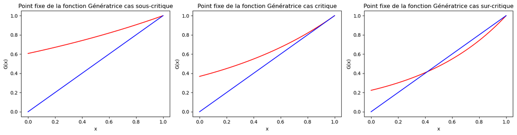

```python
import numpy as np
import matplotlib.pyplot as plt
l1,l2,l3=0.5,1,1.5 #paramètre lambda
x=np.linspace(0,1,1000)
g1,g2,g3=np.exp(-l1*(1-x)),np.exp(-l2*(1-x)),np.exp(-l3*(1-x)) # Fonction génératrice d'une loi de poisson de paramètre lambda
plt.figure(figsize=(15, 4))
plt.subplot(1,3,1)
plt.plot(x,g1,color='r')
plt.plot(x,x,color='blue')
plt.title('Point fixe de la fonction Génératrice cas sous-critique')
plt.xlabel('x')
plt.ylabel('G(x)')
plt.subplot(1,3,2)
plt.plot(x,g2,color='r')
plt.plot(x,x,color='blue')
plt.title('Point fixe de la fonction Génératrice cas critique')
plt.xlabel('x')
plt.ylabel('G(x)')
plt.subplot(1,3,3)
plt.plot(x,g3,color='r')
plt.plot(x,x,color='blue')
plt.title('Point fixe de la fonction Génératrice cas sur-critique')
plt.xlabel('x')
plt.ylabel('G(x)')

plt.tight_layout(rect=[0, 0, 1, 1])
```

#### Proposition

$E[Z_n] = m^{\,n}$